# Analysis 5, Seedling Growth by genus : Pinus

Carmen

March 3, 2017

- Main goal: see if it makes sense to add pila to existing pipo seedling growth model

## Look for the model with the best AIC

```r
dfPinus <- df[df$Species %in% c("PIPO","PILA") & !df$Fire %in% c("PLKN","WRTS"),]
varPower <- varPower(form=~Ht.cm)

table <- data.frame(model=character(),
                 AIC=numeric(), stringsAsFactors=FALSE)

M1F.pinus <- gls(LastYearGrth.cm ~ Ht.cm + Cov1.2 + BasDia.cm + Ht1.3 + Fire + Fire*Ht.cm + Ht.cm*Ht1.3,
                weights = varPower,
                 data= dfPinus, method = "ML")
AIC(M1F.pinus)
```

```
## [1] 590.7866
```

```r
table[1,] <- c("M1F.pinus", AIC(M1F.pinus))


M2F.pinus <- gls(LastYearGrth.cm ~ Ht.cm + Cov1.2 + BasDia.cm + Ht1.3 + Fire  + Fire*Ht.cm +IAG + Ht.cm*Ht1.3,
                weights = varPower,
                 data= dfPinus, method = "ML")
AIC(M2F.pinus)
```

```
## [1] 598.24
```

```r
table[2,] <- c("M2F.pinus", AIC(M2F.pinus))

M3F.pinus <- gls(LastYearGrth.cm ~  Ht.cm + Cov1.2 + BasDia.cm + Ht1.3 + Fire  + Fire*Ht.cm +IAG ,
                weights = varPower,
                 data= dfPinus, method = "ML")
AIC(M3F.pinus)
```

```
## [1] 601.9022
```

```r
table[3,] <- c("M3F.pinus", AIC(M3F.pinus))

M4F.pinus <- gls(LastYearGrth.cm ~ Ht.cm + Cov1.3 + BasDia.cm + Ht1.3 + Fire  + Fire*Ht.cm +Ht.cm*Ht1.3,
                weights = varPower,
                 data= dfPinus, method = "ML")
AIC(M4F.pinus)
```

```
## [1] 590.9168
```

```r
table[4,] <- c("M4F.pinus", AIC(M4F.pinus))

M5F.pinus <- gls(LastYearGrth.cm ~ Ht.cm + Cov1.2 + Ht1.3 + Fire  + Fire*Ht.cm + Ht.cm*Ht1.3,
                weights = varPower,
                 data= dfPinus, method = "ML")
AIC(M5F.pinus)
```

```
## [1] 591.9013
```

```r
table[5,] <- c("M5F.pinus", AIC(M5F.pinus))

M6F.pinus <- gls(LastYearGrth.cm ~ Ht.cm + Cov1.2 + BasDia.cm + Ht1.2 + Fire + Fire*Ht.cm + Ht.cm*Ht1.2,
                weights = varPower,
                 data= dfPinus, method = "ML")
AIC(M6F.pinus)
```

```
## [1] 591.9249
```

```r
table[6,] <- c("M6F.pinus", AIC(M6F.pinus))

M7F.pinus <- gls(LastYearGrth.cm ~ Ht.cm + Cov1.2 + BasDia.cm + Ht1 + Fire + Fire*Ht.cm + Ht.cm*Ht1.3,
                weights = varPower,
                 data= dfPinus, method = "ML")
AIC(M7F.pinus)
```

```
## [1] 592.7679
```

```r
table[7,] <- c("M7F.pinus", AIC(M7F.pinus))

table
```

```
##       model              AIC
## 1 M1F.pinus 590.786647904529
## 2 M2F.pinus 598.239987587907
## 3 M3F.pinus 601.902239423362
## 4 M4F.pinus 590.916770598564
## 5 M5F.pinus 591.901250689396
## 6 M6F.pinus 591.924870407172
## 7 M7F.pinus 592.767945380597
```

## Try to refine further by using different cover segments and height segments

```r
M8F.pinus <- gls(LastYearGrth.cm ~ Ht.cm +  BasDia.cm + Cov1.3 + Ht1.2 + Fire + Fire*Ht.cm + Ht.cm*Ht1.2,
                weights = varPower,
                 data= dfPinus, method = "ML")
AIC(M8F.pinus)
```

```
## [1] 591.9674
```

```r
table <- rbind(table, c("M8F.pinus", AIC(M8F.pinus)))

M9F.pinus = update(M8F.pinus, . ~ . - Cov1.3 + Cov1.2)
AIC(M9F.pinus)
```

```
## [1] 591.9249
```

```r
table <- rbind(table, c("M9F.pinus", AIC(M9F.pinus)))

M10F.pinus = update(M8F.pinus, . ~ . - Cov1.3 + Cov1)
AIC(M10F.pinus)
```

```
## [1] 592.52
```

```r
table <- rbind(table, c("M10F.pinus", AIC(M10F.pinus)))

M11F.pinus = update(M8F.pinus, . ~ . - Cov1.3 + Cov1.2 - Ht1.2 + Ht1.3 - Ht.cm*Ht1.2 + Ht.cm*Ht1.3)
AIC(M10F.pinus)
```

```
## [1] 592.52
```

```r
table <- rbind(table, c("M11F.pinus", AIC(M11F.pinus)))

M12F.pinus = update(M1F.pinus, . ~ . - BasDia.cm)
AIC(M12F.pinus)
```

```
## [1] 591.9013
```

```r
table <- rbind(table, c("M12F.pinus", AIC(M12F.pinus)))
anova(M12F.pinus, M1F.pinus)
```

```
##            Model df      AIC      BIC    logLik   Test  L.Ratio p-value
## M12F.pinus     1 13 591.9013 627.0075 -282.9506
## M1F.pinus      2 14 590.7866 628.5934 -281.3933 1 vs 2 3.114603  0.0776
```

```r
M13F.pinus =  update(M1F.pinus, . ~ . + ImmedAboveHt.cm)
AIC(M13F.pinus)
```

```
## [1] 592.6575
```

```r
table <- rbind(table, c("M13F.pinus", AIC(M13F.pinus)))

M13F.pinus <- gls(LastYearGrth.cm ~ Ht.cm + Ht1.3 + Fire + Fire*Ht.cm + Ht.cm*Ht1.3,
                weights = varPower,
                 data= dfPinus, method = "ML")
AIC(M13F.pinus)
```

```
## [1] 592.6261
```

```r
table
```

```
##         model              AIC
## 1   M1F.pinus 590.786647904529
## 2   M2F.pinus 598.239987587907
## 3   M3F.pinus 601.902239423362
## 4   M4F.pinus 590.916770598564
## 5   M5F.pinus 591.901250689396
## 6   M6F.pinus 591.924870407172
## 7   M7F.pinus 592.767945380597
## 8   M8F.pinus 591.967440031124
## 9   M9F.pinus 591.924870407172
## 10 M10F.pinus 592.520044112899
## 11 M11F.pinus 590.786647904529
## 12 M12F.pinus 591.901250689396
## 13 M13F.pinus 592.657486313895
```

## Show these models graphically

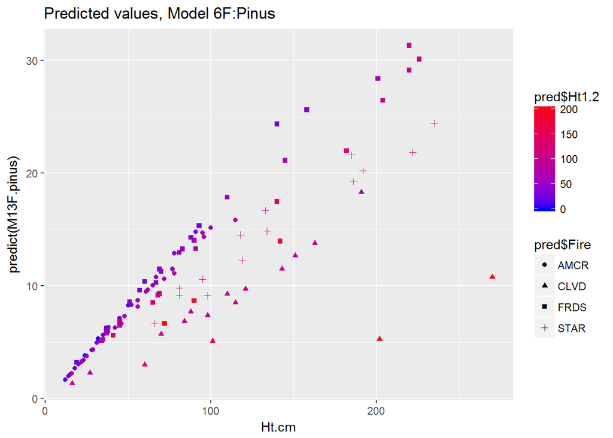

```r
pred <- as.data.frame(predict(M13F.pinus))
pred$Cov <- dfPinus$Cov1.2
pred$Ht1.2 <- dfPinus$Ht1.2
pred$Ht.cm <- dfPinus$Ht.cm
pred$Fire <- dfPinus$Fire
pred$Grth <- dfPinus$LastYearGrth.cm
pred$ShrG1 <- dfPinus$ShrG1
pred$Species <- dfPinus$Species
#pred <- arrange(pred, predict(M3.lme))
library(ggplot2)
ggplot(pred)+
  geom_point(aes(y=predict(M13F.pinus),x=Ht.cm,col=pred$Ht1.2, shape=pred$Fire))+
  scale_color_gradient(low="blue",high="red")+
  labs(title = "Predicted values, Model 6F:Pinus")
```

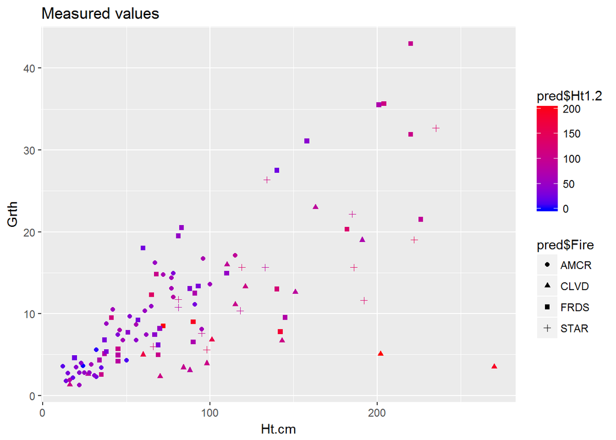

```r
ggplot(pred)+
  geom_point(aes(y=Grth,x=Ht.cm,col=pred$Ht1.2, shape=pred$Fire))+
  scale_color_gradient(low="blue",high="red")+
  labs(title = "Measured values")
```

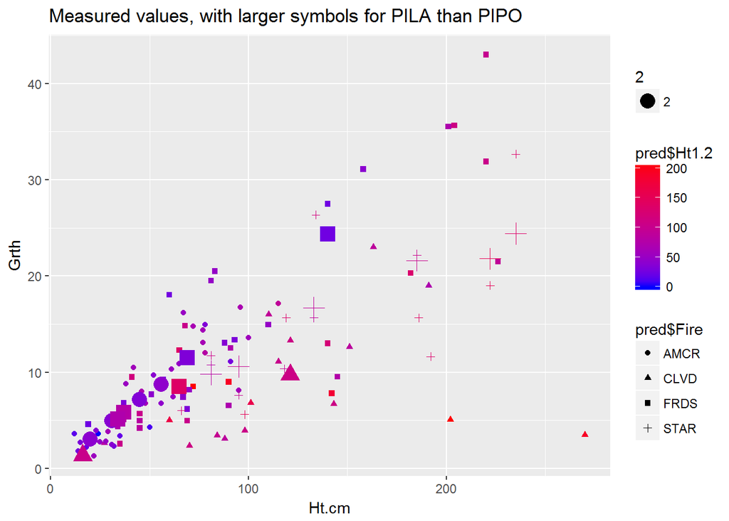

```r
pila <- pred[pred$Species=="PILA",]
ggplot(pred)+
  geom_point(aes(y=Grth,x=Ht.cm,col=pred$Ht1.2, shape=pred$Fire))+
  geom_point(data=pila, aes(y=pila[1],x=pila$Ht.cm, size=2, shape=pila$Fire, col=pila$Ht1.2))+
  scale_color_gradient(low="blue",high="red")+
  labs(title = "Measured values, with larger symbols for PILA than PIPO")
```

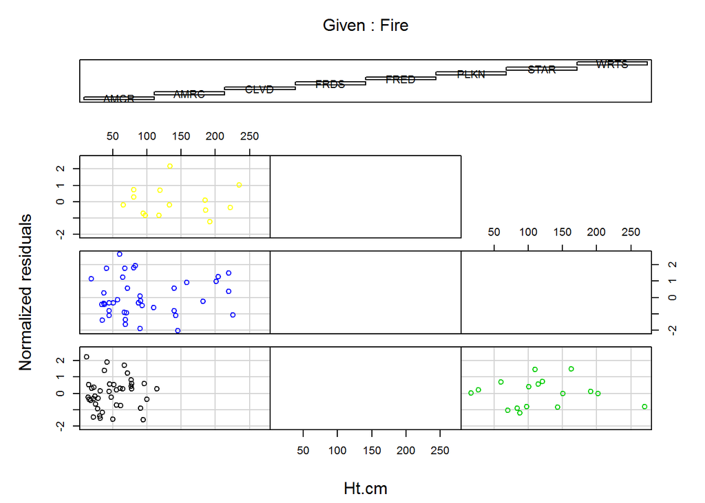

```r
E.pinus <- resid(M13F.pinus, type="normalized")
coplot(E.pinus ~ Ht.cm | Fire, data=dfPinus, ylab="Normalized residuals", col=dfPinus$Fire)
```

- The predicted values and the residuals look good
- Are the different slopes caused by different shrub heights or covers in different patches (ie covariance between fire and shrub heights or covers or shrub species?)

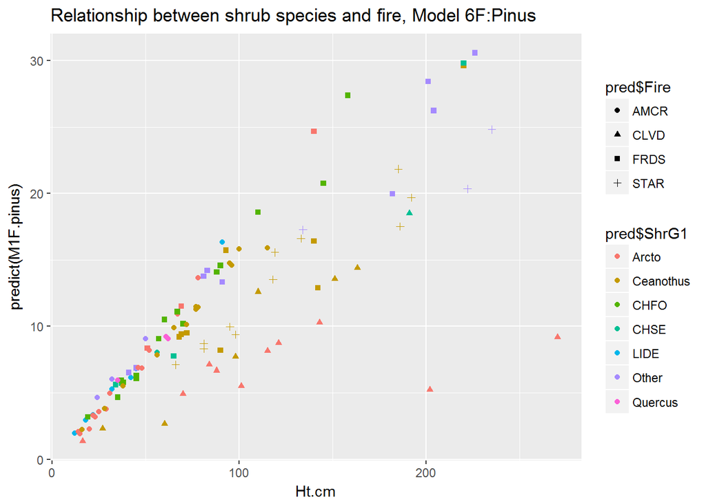

```r
ggplot(pred)+
  geom_point(aes(y=predict(M1F.pinus),x=Ht.cm,col=pred$ShrG1, shape=pred$Fire))+
  labs(title = "Relationship between shrub species and fire, Model 6F:Pinus")
```

- It appears there is a relationship but the shrub species in the flatter-sloped fires are also in other fires
- Potential conclusions from comparing abco and pinus results
  - basal diameter matters for ABCO but not for Pinus
  - shrub cover almost matters for Pinus but not for ABCO

## Now double check that I’m using the best GLS

```r
library(nlme)
# None
M1Fa.pinus <-  gls(LastYearGrth.cm ~ Ht.cm + Cov1.2 + BasDia.cm + Ht1.3 + Fire +Fire * Ht.cm + Ht.cm * Ht1.3 ,
                 data= dfPinus, method = "ML")
AIC(M1Fa.pinus)
```

```
## [1] 631.875
```

```r
table <- rbind(table, c("M1Fa.pinus", AIC(M1Fa.pinus)))

table[2,] <- c("M2F.pinus", AIC(M2F.pinus))

M1Fb.pinus <- gls(LastYearGrth.cm ~Ht.cm + Cov1.2 + BasDia.cm + Ht1.3 + Fire +Fire * Ht.cm + Ht.cm * Ht1.3 ,
                weights = varExp(form=~ Ht.cm),
                 data= dfPinus, method = "ML")
AIC(M1Fb.pinus)
```

```
## [1] 600.3151
```

```r
table <- rbind(table, c("M1Fb.pinus", AIC(M1Fb.pinus)))

M1Fc.pinus <- gls(LastYearGrth.cm ~ Ht.cm + Cov1.2 + BasDia.cm + Ht1.3 + Fire +Fire * Ht.cm + Ht.cm * Ht1.3 ,
                weights = varConstPower(form=~Ht.cm),
                 data= dfPinus, method = "ML")
AIC(M1Fc.pinus)
```

```
## [1] 592.7866
```

```r
table <- rbind(table, c("M1Fc.pinus", AIC(M1Fc.pinus)))

table
```

```
##         model              AIC
## 1   M1F.pinus 590.786647904529
## 2   M2F.pinus 598.239987587907
## 3   M3F.pinus 601.902239423362
## 4   M4F.pinus 590.916770598564
## 5   M5F.pinus 591.901250689396
## 6   M6F.pinus 591.924870407172
## 7   M7F.pinus 592.767945380597
## 8   M8F.pinus 591.967440031124
## 9   M9F.pinus 591.924870407172
## 10 M10F.pinus 592.520044112899
## 11 M11F.pinus 590.786647904529
## 12 M12F.pinus 591.901250689396
## 13 M13F.pinus 592.657486313895
## 14 M1Fa.pinus 631.874960300926
## 15 M1Fb.pinus 600.315071403803
## 16 M1Fc.pinus 592.786648000922
```

## Try the same model but with DIFN!

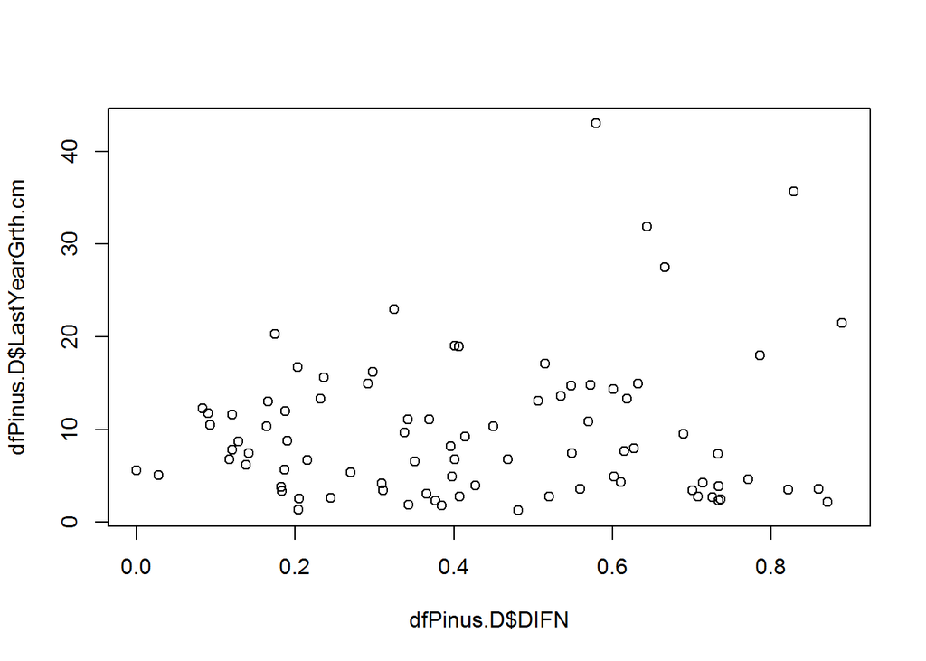

```r
dfPinus.D <- dfPinus[!is.na(dfPinus$DIFN),]
plot(dfPinus.D$DIFN, dfPinus.D$LastYearGrth.cm)
```

```r
tableDIFN <- data.frame(model=character(),
                 AIC=numeric(), stringsAsFactors=FALSE)

M1D.pinus <- gls(LastYearGrth.cm ~ Ht.cm + Cov1.2 + BasDia.cm + DIFN + Fire +Fire * Ht.cm + Ht.cm*DIFN,
                weights = varPower,
                 data= dfPinus.D, method = "ML")
AIC(M1D.pinus)
```

```
## [1] 452.2602
```

```r
tableDIFN[1,] <- c("M1D.pinus", AIC(M1D.pinus))

M2D.pinus <- gls(LastYearGrth.cm ~ Ht.cm + Cov1.2 + BasDia.cm + Ht1.3 + Fire +Fire * Ht.cm + Ht.cm * Ht1.3,
                weights = varPower,
                 data= dfPinus.D, method = "ML")
AIC(M2D.pinus)
```

```
## [1] 448.3372
```

```r
anova(M1D.pinus, M2D.pinus)
```

```
##           Model df      AIC      BIC    logLik
## M1D.pinus     1 14 452.2602 486.6210 -212.1301
## M2D.pinus     2 14 448.3372 482.6981 -210.1686
```

```r
M3D.pinus <- gls(LastYearGrth.cm ~ Ht.cm + Cov1.2 + BasDia.cm + DIFN + Fire +Fire * Ht.cm,
                weights = varPower,
                 data= dfPinus.D, method = "ML")
AIC(M3D.pinus)
```

```
## [1] 450.2602
```

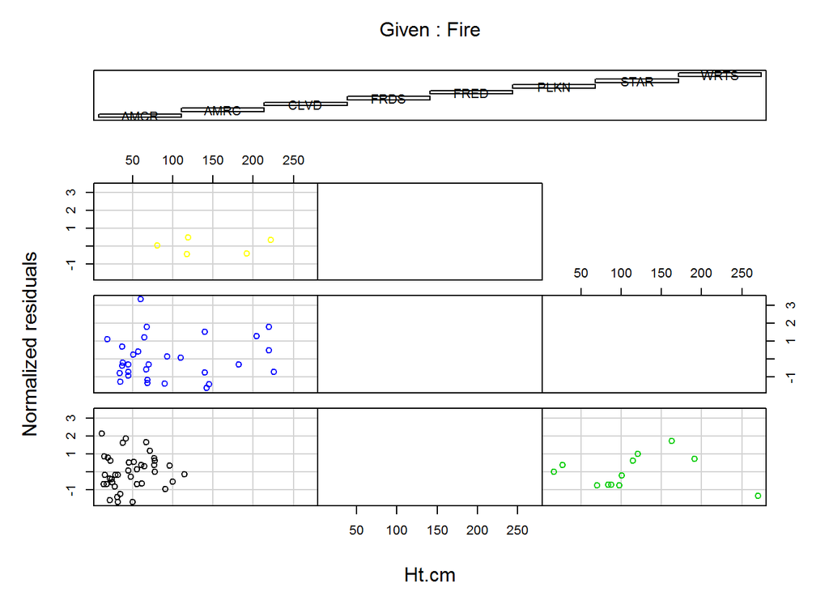

```r
E1D.pinus <- resid(M1D.pinus, type="normalized")
coplot(E1D.pinus ~ Ht.cm | Fire, data=dfPinus.D, ylab="Normalized residuals", main="DIFN model residuals", col=dfPinus.D$Fire)
```

```r
M2D.pinus <- lme(LastYearGrth.cm ~ Ht.cm + Ht1 + BasDia.cm,
                random=~1+Ht1|Fire,
                weights = varPower,
                 data= dfPinus.D,
                method = "ML")
AIC(M2D.pinus)
```

```
## [1] 459.7293
```

```r
M4D.pinus <- gls(LastYearGrth.cm ~ Ht.cm + + DIFN + Fire + Fire*Ht.cm,
                weights = varPower,
                 data= dfPinus.D, method = "ML")
AIC(M4D.pinus)
```

```
## [1] 448.3864
```

```r
M5D.pinus <- gls(LastYearGrth.cm ~ Ht.cm + DIFN + Ht1.2 + Fire + Fire*Ht.cm,
                weights = varPower,
                 data= dfPinus.D, method = "ML")
AIC(M5D.pinus)
```

```
## [1] 443.7517
```

```r
tableDIFN <- rbind(tableDIFN, c("M5D.pinus", AIC(M5D.pinus)))

M6D.pinus <- gls(LastYearGrth.cm ~ Ht.cm + Ht1.2 + Fire + Fire*Ht.cm,
                weights = varPower,
                 data= dfPinus.D, method = "ML")
AIC(M6D.pinus)
```

```
## [1] 442.6913
```

```r
tableDIFN <- rbind(tableDIFN, c("M6D.pinus", AIC(M6D.pinus)))

tableDIFN
```

```
##       model              AIC
## 1 M1D.pinus  452.26018598484
## 2 M5D.pinus  443.75165603261
## 3 M6D.pinus 442.691327957177
```

## Main Findings

1. The best model to describe Pinus seedling growth with the data I have is

```r
M1F.pinus <- gls(LastYearGrth.cm ~ Ht.cm + Cov1.2 + BasDia.cm + Ht1.3 + Fire + Fire*Ht.cm + Ht.cm*Ht1.3,
                weights = varPower,
                 data= dfPinus, method = "ML")
AIC(M1F.pinus)
```

```
## [1] 590.7866
```

```r
M1F.pinus.2 <- gls(LastYearGrth.cm ~ Ht.cm + Ht1.3 + Fire + Fire*Ht.cm + Ht.cm*Ht1.3,
                weights = varPower,
                 data= dfPinus, method = "ML")
AIC(M1F.pinus.2)
```

```
## [1] 592.6261
```

- Must rerun it with REML for parameter estimation - important!
- For the purposes of SORTIE, having basal diameter in there is not that helpful. Plus it is only marginally significant in the model. Also, the effect of shrub cover is tiny so I’ll delete that too. So the SORTIE model should be

```r
SORTIE_pinus <- gls(LastYearGrth.cm ~ Ht.cm + Ht1.3 + Fire + Fire*Ht.cm + Ht.cm*Ht1.3,
                weights = varPower,
                 data= dfPinus, method = "REML")
summary(SORTIE_pinus)
```

```
## Generalized least squares fit by REML
##   Model: LastYearGrth.cm ~ Ht.cm + Ht1.3 + Fire + Fire * Ht.cm + Ht.cm *      Ht1.3
##   Data: dfPinus
##        AIC      BIC    logLik
##   637.0697 668.3317 -306.5348
##
## Variance function:
##  Structure: Power of variance covariate
##  Formula: ~Ht.cm
##  Parameter estimates:
##     power
## 0.7481581
##
## Coefficients:
##                     Value Std.Error   t-value p-value
## (Intercept)    -0.5984835  0.794900 -0.752904  0.4533
## Ht.cm           0.1870188  0.018519 10.098796  0.0000
## Ht1.3           0.0068351  0.016058  0.425662  0.6713
## FireCLVD       -0.0801668  1.666351 -0.048109  0.9617
## FireFRDS        0.3021076  1.136367  0.265854  0.7909
## FireSTAR       -1.1095746  3.939541 -0.281651  0.7788
## Ht.cm:FireCLVD -0.0501255  0.027773 -1.804808  0.0741
## Ht.cm:FireFRDS  0.0012349  0.022202  0.055621  0.9558
## Ht.cm:FireSTAR -0.0040670  0.039511 -0.102933  0.9182
## Ht.cm:Ht1.3    -0.0005397  0.000220 -2.453205  0.0159
##
##  Correlation:
##                (Intr) Ht.cm  Ht1.3  FrCLVD FrFRDS FrSTAR H.:FCL H.:FFR
## Ht.cm          -0.729
## Ht1.3          -0.738  0.303
## FireCLVD        0.296  0.004 -0.689
## FireFRDS       -0.014  0.156 -0.392  0.422
## FireSTAR        0.210 -0.061 -0.397  0.318  0.227
## Ht.cm:FireCLVD -0.105 -0.155  0.522 -0.776 -0.459 -0.295
## Ht.cm:FireFRDS  0.147 -0.379  0.297 -0.395 -0.811 -0.215  0.626
## Ht.cm:FireSTAR -0.137 -0.063  0.447 -0.418 -0.359 -0.876  0.545  0.475
## Ht.cm:Ht1.3     0.638 -0.520 -0.791  0.557  0.378  0.360 -0.617 -0.387
##                H.:FST
## Ht.cm
## Ht1.3
## FireCLVD
## FireFRDS
## FireSTAR
## Ht.cm:FireCLVD
## Ht.cm:FireFRDS
## Ht.cm:FireSTAR
## Ht.cm:Ht1.3    -0.526
##
## Standardized residuals:
##        Min         Q1        Med         Q3        Max
## -1.9729771 -0.7776318 -0.1427274  0.5390758  2.5200848
##
## Residual standard error: 0.1418494
## Degrees of freedom: 110 total; 100 residual
```

2. DIFN is not useful for Pinus
3. Shrub cover is not super important but shrub height is
4. Shrub genus does not appear to be important

## Graphically display predictions for a set of fake values

```r
Ht.cm <- c(rep(seq(0,300,5),4))
length(Ht.cm)
```

```
## [1] 244
```

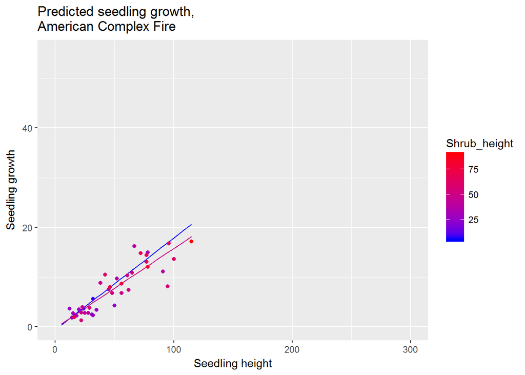

```r
fakedata <- as.data.frame(Ht.cm)
fakedata$Ht1.3 <- c(rep(c(5,50,100,150),61))
fakedata$Fire <- as.factor(c(rep("AMCR",244)))
predicted <- predict(SORTIE_pinus, fakedata)

pred <- as.data.frame(predicted)
pred$Shrub_height <- fakedata$Ht1.3
pred$Ht.cm <- fakedata$Ht.cm
pred$Fire <- fakedata$Fire

dfCLVD <- subset(dfPinus, dfPinus$Fire=="CLVD" & !is.na(dfPinus$LastYearGrth.cm))
dfAMCR<- subset(dfPinus, dfPinus$Fire=="AMCR" & !is.na(dfPinus$LastYearGrth.cm))
dfFRDS <- subset(dfPinus, dfPinus$Fire=="FRDS" & !is.na(dfPinus$LastYearGrth.cm))
dfSTAR <- subset(dfPinus, dfPinus$Fire=="STAR" & !is.na(dfPinus$LastYearGrth.cm))

plot_AMCR <- ggplot(pred[pred$Shrub_height<51&pred$Ht.cm <= max(dfAMCR$Ht.cm),])+
  geom_line(aes(y= predicted ,x=Ht.cm,group=Shrub_height,col=Shrub_height))+
  scale_color_gradient(low="blue",high="red")+
  labs(title = "Predicted seedling growth,\nAmerican Complex Fire")+
  ylim(0,55)+
  xlim(0,300)+
  geom_point(data=dfAMCR,aes(y=LastYearGrth.cm,x=Ht.cm,col=Ht1.3))+
  xlab("Seedling height")+
  ylab("Seedling growth")

plot_AMCR
```

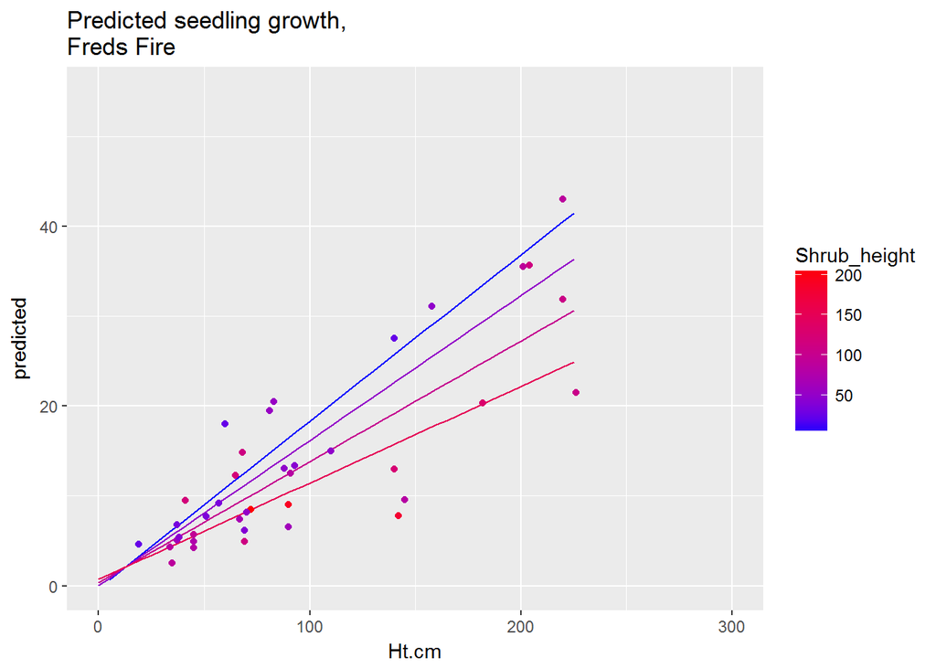

```r
fakedata$Fire <- as.factor(c(rep("CLVD",244)))
predicted <- predict(SORTIE_pinus, fakedata)
pred <- as.data.frame(predicted)
pred$Shrub_height <- fakedata$Ht1.3
pred$Ht.cm <- fakedata$Ht.cm
pred$Fire <- fakedata$Fire
pred$Grth <- fakedata$LastYearGrth.cm

predicted_clvd <- predicted

CLVD <- ggplot(pred[pred$Ht.cm<=max(dfCLVD$Ht.cm),])+
  geom_line(aes(y= predicted ,x=Ht.cm,group=Shrub_height,col=Shrub_height))+
  scale_color_gradient(low="blue",high="red")+
  labs(title = "Predicted seedling growth,\nCleveland Fire")+
  ylim(0,55)+
  xlim(0,300)+
  geom_point(data=dfCLVD,aes(y=LastYearGrth.cm,x=Ht.cm,col=Ht1.3))+
  xlab("Seedling height")+
  ylab("Seedling growth")


fakedata$Fire <- as.factor(c(rep("FRDS",244)))
predicted <- predict(SORTIE_pinus, fakedata)
pred <- as.data.frame(predicted)
pred$Shrub_height <- fakedata$Ht1.3
pred$Ht.cm <- fakedata$Ht.cm
pred$Fire <- fakedata$Fire
pred$Grth <- fakedata$LastYearGrth.cm

predicted_freds <- predicted

FRDS <- ggplot(pred[pred$Ht.cm<=max(dfFRDS$Ht.cm),])+
  geom_line(aes(y= predicted ,x=Ht.cm,group=Shrub_height,col=Shrub_height))+
  scale_color_gradient(low="blue",high="red")+
  labs(title = "Predicted seedling growth,\nFreds Fire")+
  ylim(0,55)+
  xlim(0,300)+
  geom_point(data=dfFRDS,aes(y=LastYearGrth.cm,x=Ht.cm,col=Ht1.3))

FRDS
```

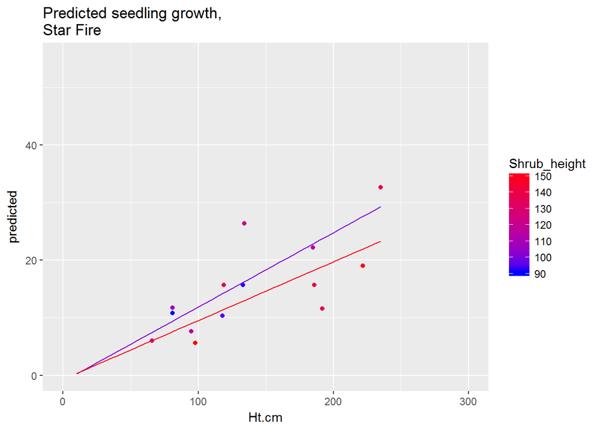

```r
fakedata$Fire <- as.factor(c(rep("STAR",244)))
predicted <- predict(SORTIE_pinus, fakedata)
pred <- as.data.frame(predicted)
pred$Shrub_height <- fakedata$Ht1.3
pred$Ht.cm <- fakedata$Ht.cm
pred$Fire <- fakedata$Fire
pred$Grth <- fakedata$LastYearGrth.cm

STAR <- ggplot(pred[pred$Shrub_height>51&pred$Ht.cm <= max(dfSTAR$Ht.cm),])+
  geom_line(aes(y= predicted,x=Ht.cm,group=Shrub_height,col=Shrub_height))+
  scale_color_gradient(low="blue",high="red")+
  labs(title = "Predicted seedling growth,\nStar Fire")+
  ylim(0,55)+
  xlim(0,300)+
  geom_point(data=dfSTAR,aes(y=LastYearGrth.cm,x=Ht.cm,col=Ht1.3))

STAR
```

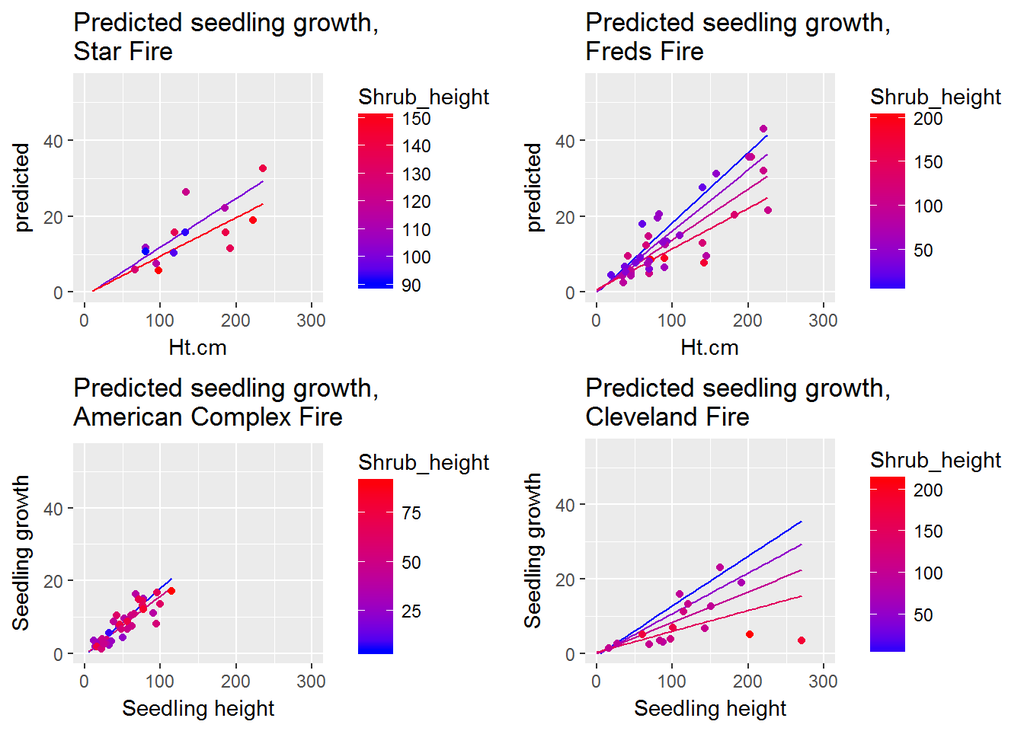

```r
grid.arrange(STAR, FRDS,plot_AMCR,CLVD,ncol=2,nrow=2)
```

## How do these results inform my initial SORTIE inputs?

- How do I deal with non-continuous shrub cover given that this model only takes shrub height into consideration?

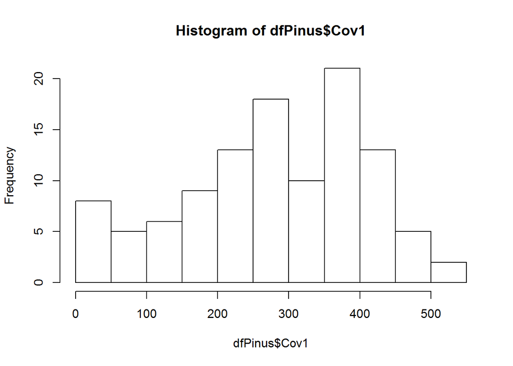

```r
hist(dfPinus$Cov1)
```

```r
nrow(dfPinus[dfPinus$Cov1<100,])
```

```
## [1] 10
```

- There are only 10 pine observations that have seedlings with less than 100 cm shrub cover across 4 1-m transects
- Perhaps for the seedlings with less than 100 cm shrub cover, I could use a separate growth function that is not dependent upon shrubs
  - I could derive this function from Welch data, maybe

### Add variable for whether the seedling is immediately overtopped by shrubs

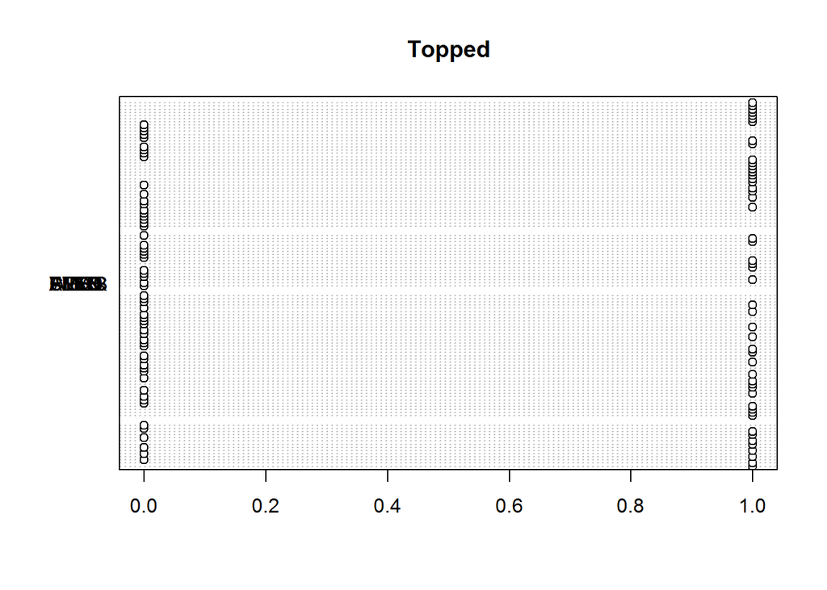

```r
dfPinus <- tbl_df(dfPinus)
dfPinus <- dfPinus%>%
  mutate(Topped = ifelse(dfPinus$ImmedAboveHt.cm>0,1,0))
dotchart(dfPinus$Topped, group = dfPinus$Fire, main = "Topped")
```

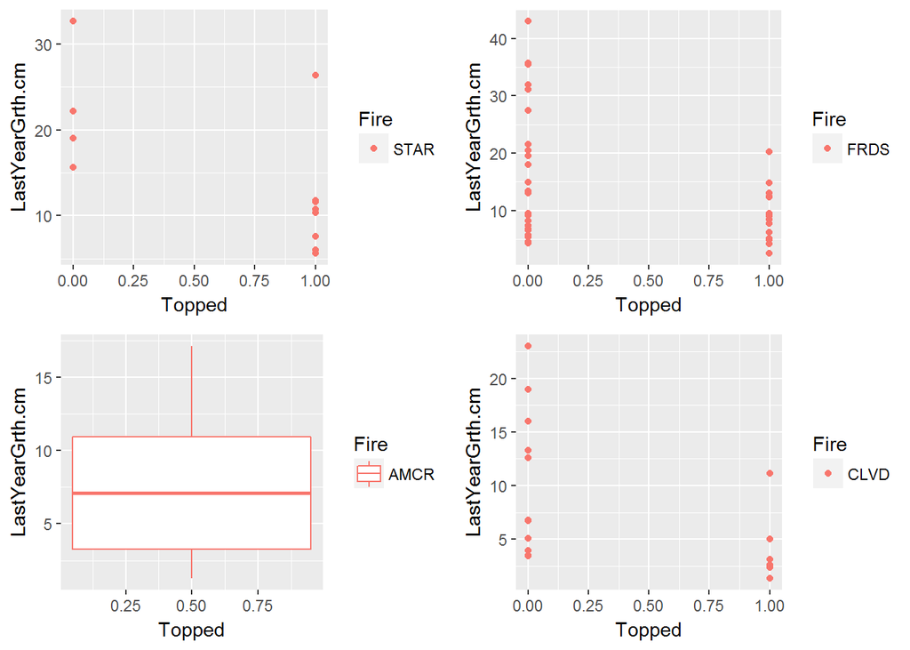

```r
top_AMCR <- ggplot(data=dfPinus[dfPinus$Fire=="AMCR",], aes(y=LastYearGrth.cm, x=Topped))+
  geom_boxplot(aes(colour = Fire))
top_STAR <- ggplot(data=dfPinus[dfPinus$Fire=="STAR",], aes(y=LastYearGrth.cm, x=Topped))+
  geom_point(aes(colour = Fire))
top_CLVD <- ggplot(data=dfPinus[dfPinus$Fire=="CLVD",], aes(y=LastYearGrth.cm, x=Topped))+
  geom_point(aes(colour = Fire))
top_FRDS <- ggplot(data=dfPinus[dfPinus$Fire=="FRDS",], aes(y=LastYearGrth.cm, x=Topped))+
  geom_point(aes(colour = Fire))
grid.arrange(top_STAR, top_FRDS,top_AMCR,top_CLVD,ncol=2,nrow=2)
```

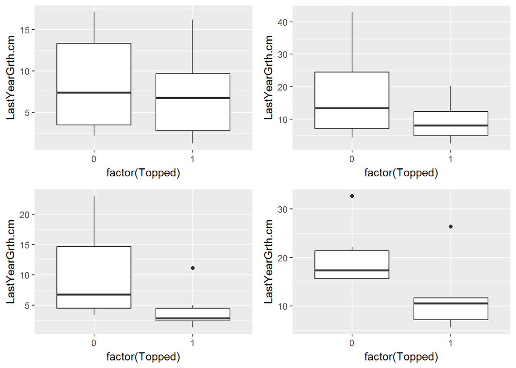

```r
box_AMCR <- ggplot(data=dfPinus[dfPinus$Fire=="AMCR",],aes(factor(Topped),LastYearGrth.cm))+
         geom_boxplot()
box_STAR <- ggplot(data=dfPinus[dfPinus$Fire=="STAR",],aes(factor(Topped),LastYearGrth.cm))+
         geom_boxplot()
box_CLVD <- ggplot(data=dfPinus[dfPinus$Fire=="CLVD",],aes(factor(Topped),LastYearGrth.cm))+
         geom_boxplot()
box_FRDS <- ggplot(data=dfPinus[dfPinus$Fire=="FRDS",],aes(factor(Topped),LastYearGrth.cm))+
         geom_boxplot()
grid.arrange(box_AMCR, box_FRDS, box_CLVD, box_STAR, ncol=2,nrow=2)
```

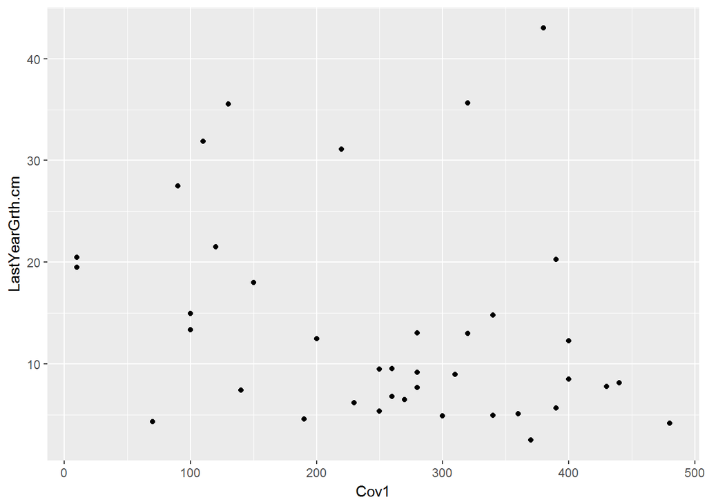

```r
ggplot(data=dfPinus[dfPinus$Fire=="FRDS",],aes(y=LastYearGrth.cm,x=Cov1))+
         geom_point()
```

- Look at whether there’s a pattern in the residuals for seedlings with different cover attributes that can inform me on where the shrub cover threshold is below which shrub height doesn’t matter for seedling growth
- Also look at residuals for PILA compared to PIPO
- First, check that residuals are in the same order as the dfPinus data and predictions

```r
head(dfPinus$LastYearGrth.cm-residuals(SORTIE_pinus))
```

```
##         1         2         4         5         8        10
##  9.751273 11.517249  7.703082 18.349235  9.308997 13.805831
```

```r
head(predict(SORTIE_pinus))
```

```
##         1         2         4         5         8        10
##  9.751273 11.517249  7.703082 18.349235  9.308997 13.805831
```

- Good.

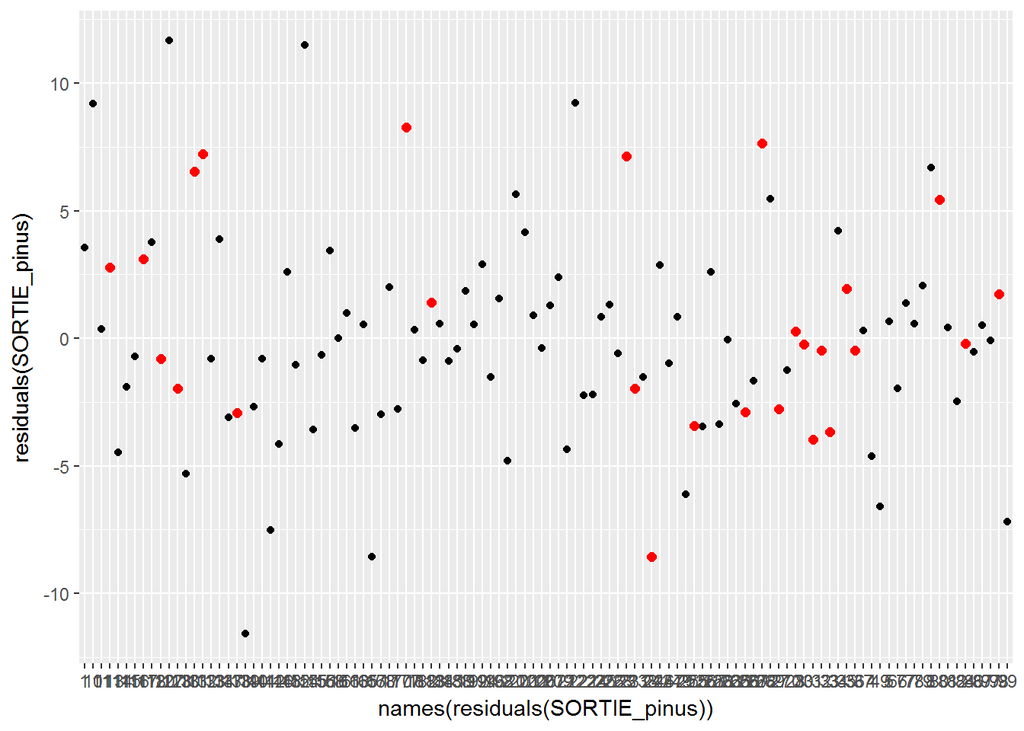

```r
ggplot()+
  geom_point(aes(y=residuals(SORTIE_pinus),x=names(residuals(SORTIE_pinus))))+
  geom_point(aes(y=residuals(SORTIE_pinus)[dfPinus$Cov1<200],x=names(residuals(SORTIE_pinus)[dfPinus$Cov1<200])),color="red",size=2)
```

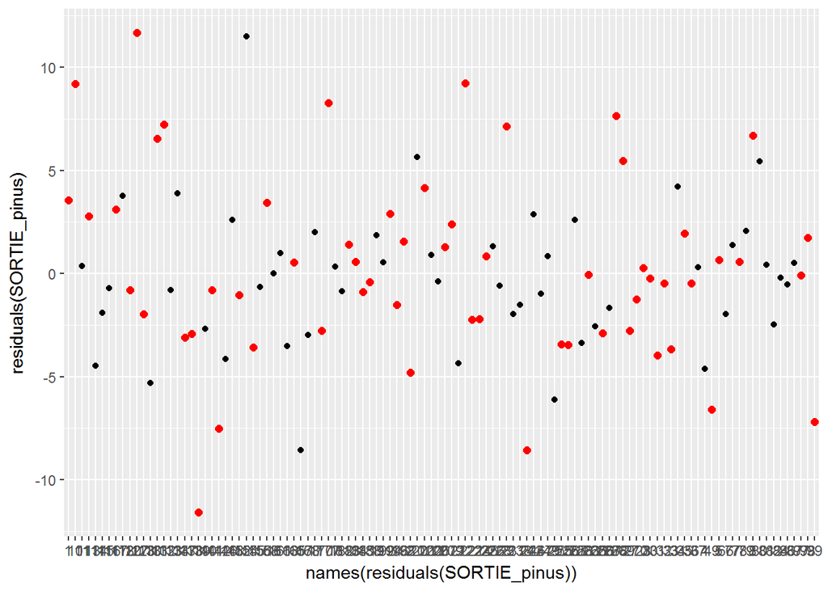

```r
ggplot()+
  geom_point(aes(y=residuals(SORTIE_pinus),x=names(residuals(SORTIE_pinus))))+
  geom_point(aes(y=residuals(SORTIE_pinus)[dfPinus$Topped==0],x=names(residuals(SORTIE_pinus)[dfPinus$Topped==0])),color="red",size=2)
```

```r
length(residuals(SORTIE_pinus)[residuals(SORTIE_pinus)>0])
```

```
## [1] 52
```

```r
length(residuals(SORTIE_pinus)[residuals(SORTIE_pinus)<0])
```

```
## [1] 58
```

```r
length(residuals(SORTIE_pinus)[dfPinus$Cov1<300&residuals(SORTIE_pinus)<0])
```

```
## [1] 30
```

```r
length(residuals(SORTIE_pinus)[dfPinus$Cov1<300&residuals(SORTIE_pinus)>0])
```

```
## [1] 25
```